# Reliability of paediatric MRI

Vlad Drobinin

```r
library(here)
source(here::here("R", "0-load-functions.R"))
source(here::here("R", "1-import-ICC.R"))

# clear 2 digit output
options(scipen = 2, digits = 2)
```

# Reliability (ICC)

> The ICC can be interpreted as “the proportion of the variance explained by the grouping structure in the population”

ICCs are classified according to Cicchetti as

- poor (<0.40)
- fair (0.41–0.59)
- good (> 0.59 – 0.74)
- excellent (> 0.74)

## Main functions

- Click the code button on the right to expand text field containing the primary functions used in this analysis.
- They primarily rely on the `tidyverse` series of packages for data wrangling and the `ICCest` package for ICC calculations.

```r
# Helper functions using ICCest package to calc ICC and CI
est_lower_icc <- function(x){ICCest(scan_id, value, data = x)$LowerCI}
est_icc <- function(x){ICCest(scan_id, value, data = x)$ICC}
est_upper_icc <- function(x){ICCest(scan_id, value, data = x)$UpperCI}

# ICC function
classify_icc <- function(x) {
  # this function takes a "long" data frame
  # then calculates the ICC w/ the 95% CI per ROI
  # it then classifies the ICC according to set criteria
  # finally it creates a grouping variable for the hemispheres
  x %>%
  # nest by ROI for regional output
  tidyr::nest(-ROI) %>%
  # use previously defined est_icc functions
  dplyr::mutate(
    `2.5% CI` = purrr::map(data, est_lower_icc),
    `ICC` = purrr::map(data, est_icc),
    `97.5% CI` = purrr::map(data, est_upper_icc)) %>%
  tidyr::unnest(`2.5% CI`, `ICC`, `97.5% CI`, .drop = T) %>%
  # classify based on Cicchetti
  dplyr::mutate(Classification = case_when(
    ICC > 0.74 ~ "Excellent",
    ICC <= 0.74 & ICC > 0.59 ~ "Good",
    ICC <= 0.59 & ICC > 0.40 ~ "Fair",
    ICC < 0.40  ~ "Poor")) %>%
  # create hemisphere variable
  dplyr::mutate(hemi = case_when(
    grepl("_L_", ROI) ~ "lh",
    grepl("_R_", ROI) ~ "rh",
    TRUE ~ "bilateral")
  )
}

# function to print results inline in the r notebook
print_inline_icc <- function(x){
  # overall averaged
  overall_m <- signif(mean(x$ICC), 2)
  overall_l <- signif(mean(x$"2.5% CI"), 2)
  overall_u <- signif(mean(x$"97.5% CI"), 2)
  # by hemisphere
  lh_m <- signif(mean(x[x$hemi == "lh", ]$ICC), 2)
  lh_l <- signif(mean(x[x$hemi == "lh", ]$"2.5% CI"), 2)
  lh_u <- signif(mean(x[x$hemi == "lh", ]$"97.5% CI"), 2)
  rh_m <- signif(mean(x[x$hemi == "rh", ]$ICC), 2)
  rh_l <- signif(mean(x[x$hemi == "rh", ]$"2.5% CI"), 2)
  rh_u <- signif(mean(x[x$hemi == "rh", ]$"97.5% CI"), 2)
  # print in line in notebook
  glue::glue('
  The overall ICC for this measure is M = {overall_m},
  95% CI [{overall_l}, {overall_u}].
  The left hemisphere average ICC is {lh_m}, 95% CI [{lh_l}, {lh_u}].
  The right hemisphere average ICC is {rh_m}, 95% CI [{rh_l}, {rh_u}].
  ')
}
```

# Grey matter ICC

## Figure 1

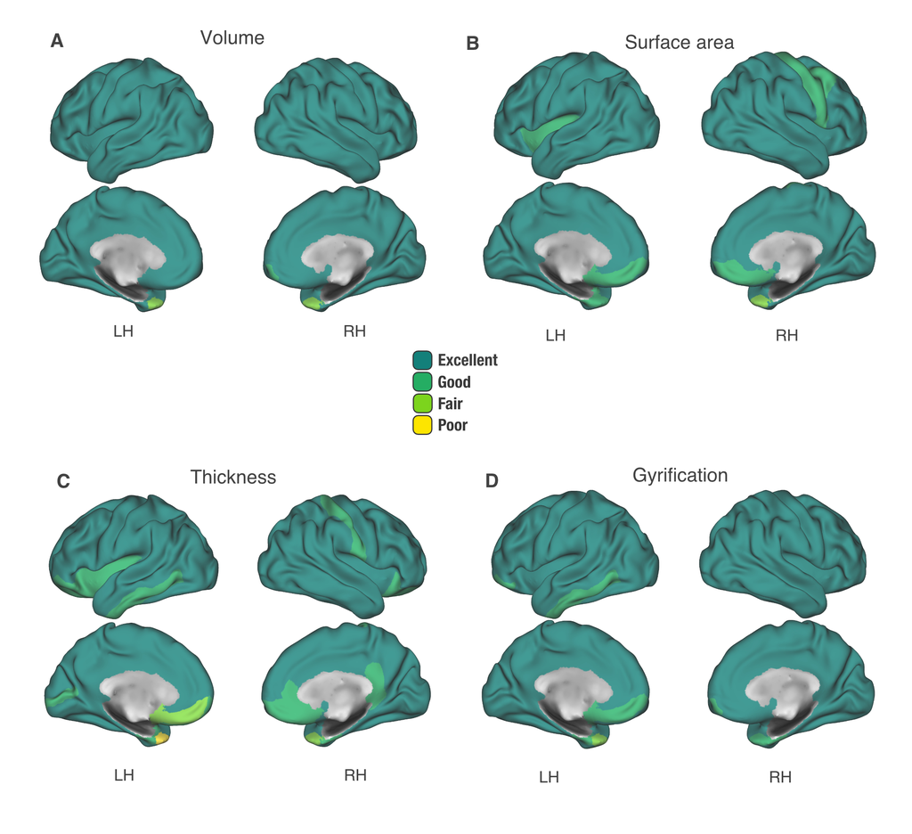

## Table 1. Grey matter volume

```r
# creates data table
gm <- df_clean %>%
  # wrangles data from wide to long and select variables of interest
  select(starts_with("scan"), contains("GrayVol")) %>%
  gather("ROI", "value", contains("GrayVol")) %>%
  # uses function defined above to calc ICC
  classify_icc()

# ROI string cleanup for table
gm$ROI <- gm$ROI %>%
  str_replace_all(c("FS_._" = "", "_GrayVol" = ""))
```

The overall ICC for this measure is M = 0.9, 95% CI [0.84, 0.94]. The left hemisphere average ICC is 0.92, 95% CI [0.86, 0.95]. The right hemisphere average ICC is 0.89, 95% CI [0.82, 0.93].

The table below shows regional ICC based on the Desikan atlas.

### Left hemisphere

```r
gm %>%
  filter(hemi == "lh") %>%
  select(-hemi)
```

| ROI | 2.5% CI | ICC | 97.5% CI | Classification |
| --- | --- | --- | --- | --- |
| Bankssts | 0.93 | 0.96 | 0.98 | Excellent |
| Caudalanteriorcingulate | 0.71 | 0.82 | 0.89 | Excellent |
| Caudalmiddlefrontal | 0.94 | 0.97 | 0.98 | Excellent |
| Cuneus | 0.92 | 0.95 | 0.97 | Excellent |
| Entorhinal | 0.72 | 0.83 | 0.90 | Excellent |
| Fusiform | 0.90 | 0.94 | 0.97 | Excellent |
| Inferiorparietal | 0.93 | 0.96 | 0.98 | Excellent |
| Inferiortemporal | 0.97 | 0.98 | 0.99 | Excellent |
| Isthmuscingulate | 0.92 | 0.95 | 0.97 | Excellent |
| Lateraloccipital | 0.91 | 0.95 | 0.97 | Excellent |

[output cut: 24 more lines]

### Right hemisphere

```r
gm %>%
  filter(hemi == "rh") %>%
  select(-hemi)
```

| ROI | 2.5% CI | ICC | 97.5% CI | Classification |
| --- | --- | --- | --- | --- |
| Bankssts | 0.91 | 0.95 | 0.97 | Excellent |
| Caudalanteriorcingulate | 0.84 | 0.91 | 0.95 | Excellent |
| Caudalmiddlefrontal | 0.72 | 0.83 | 0.90 | Excellent |
| Cuneus | 0.95 | 0.97 | 0.98 | Excellent |
| Entorhinal | 0.60 | 0.75 | 0.85 | Excellent |
| Fusiform | 0.95 | 0.97 | 0.98 | Excellent |
| Inferiorparietal | 0.96 | 0.98 | 0.99 | Excellent |
| Inferiortemporal | 0.95 | 0.97 | 0.98 | Excellent |
| Isthmuscingulate | 0.85 | 0.91 | 0.95 | Excellent |
| Lateraloccipital | 0.94 | 0.97 | 0.98 | Excellent |

[output cut: 24 more lines]

## Table 2. Surface area

```r
area <- df_clean %>%
  select(starts_with("scan"), starts_with("FS_"), -ends_with("GrayVol")) %>%
  gather("ROI", "value", contains("_Area")) %>%
  # uses function defined above to calc ICC
  classify_icc()

area$ROI <- area$ROI %>%
  str_replace_all(c("FS_._" = "", "_Area" = ""))
```

The overall ICC for this measure is M = 0.89, 95% CI [0.82, 0.93]. The left hemisphere average ICC is 0.91, 95% CI [0.85, 0.95]. The right hemisphere average ICC is 0.87, 95% CI [0.79, 0.92].

### Left hemisphere

```r
area %>%
  filter(hemi == "lh") %>%
  select(-hemi)
```

| ROI | 2.5% CI | ICC | 97.5% CI | Classification |
| --- | --- | --- | --- | --- |
| Bankssts | 0.92 | 0.96 | 0.97 | Excellent |
| Caudalanteriorcingulate | 0.80 | 0.88 | 0.93 | Excellent |
| Caudalmiddlefrontal | 0.97 | 0.98 | 0.99 | Excellent |
| Cuneus | 0.92 | 0.95 | 0.97 | Excellent |
| Entorhinal | 0.55 | 0.71 | 0.83 | Good |
| Fusiform | 0.87 | 0.93 | 0.96 | Excellent |
| Inferiorparietal | 0.93 | 0.96 | 0.98 | Excellent |
| Inferiortemporal | 0.91 | 0.95 | 0.97 | Excellent |
| Isthmuscingulate | 0.90 | 0.94 | 0.97 | Excellent |
| Lateraloccipital | 0.92 | 0.96 | 0.97 | Excellent |

[output cut: 24 more lines]

### Right hemisphere

```r
area %>%
  filter(hemi == "rh") %>%
  select(-hemi)
```

| ROI | 2.5% CI | ICC | 97.5% CI | Classification |
| --- | --- | --- | --- | --- |
| Bankssts | 0.91 | 0.94 | 0.97 | Excellent |
| Caudalanteriorcingulate | 0.83 | 0.90 | 0.94 | Excellent |
| Caudalmiddlefrontal | 0.53 | 0.70 | 0.82 | Good |
| Cuneus | 0.94 | 0.96 | 0.98 | Excellent |
| Entorhinal | 0.62 | 0.77 | 0.86 | Excellent |
| Fusiform | 0.95 | 0.97 | 0.98 | Excellent |
| Inferiorparietal | 0.96 | 0.98 | 0.99 | Excellent |
| Inferiortemporal | 0.92 | 0.96 | 0.97 | Excellent |
| Isthmuscingulate | 0.86 | 0.92 | 0.95 | Excellent |
| Lateraloccipital | 0.97 | 0.98 | 0.99 | Excellent |

[output cut: 24 more lines]

## Table 3. Thickness

```r
thick <- df_clean %>%
  select(starts_with("scan"), starts_with("FS_"), -ends_with("GrayVol")) %>%
  gather("ROI", "value", contains("_Thck")) %>%
  classify_icc()

thick$ROI <- thick$ROI %>%
  str_replace_all(c("FS_._" = "", "_Thck" = ""))
```

The overall ICC for this measure is M = 0.82, 95% CI [0.71, 0.89]. The left hemisphere average ICC is 0.83, 95% CI [0.73, 0.9]. The right hemisphere average ICC is 0.81, 95% CI [0.69, 0.88].

### Left hemisphere

```r
thick %>%
  filter(hemi == "lh") %>%
  select(-hemi)
```

[output not shown]

### Right hemisphere

```r
thick %>%
  filter(hemi == "rh") %>%
  select(-hemi)
```

| ROI | 2.5% CI | ICC | 97.5% CI | Classification |
| --- | --- | --- | --- | --- |
| Bankssts | 0.86 | 0.92 | 0.95 | Excellent |
| Caudalanteriorcingulate | 0.72 | 0.83 | 0.90 | Excellent |
| Caudalmiddlefrontal | 0.85 | 0.91 | 0.95 | Excellent |
| Cuneus | 0.80 | 0.88 | 0.93 | Excellent |
| Entorhinal | 0.39 | 0.60 | 0.75 | Good |
| Fusiform | 0.73 | 0.84 | 0.90 | Excellent |
| Inferiorparietal | 0.88 | 0.93 | 0.96 | Excellent |
| Inferiortemporal | 0.80 | 0.88 | 0.93 | Excellent |
| Isthmuscingulate | 0.55 | 0.71 | 0.83 | Good |
| Lateraloccipital | 0.76 | 0.86 | 0.92 | Excellent |

[output cut: 24 more lines]

## Table 4. Cortical folding (LGI)

```r
lgi <- df_clean %>%
  select(starts_with("scan"), starts_with("LGI"), -ends_with("Area")) %>%
  gather("ROI", "value", contains("Mean")) %>%
  classify_icc()

lgi$ROI <- lgi$ROI %>%
  str_replace_all(c("LGI_._" = "", "_Mean" = ""))
```

The overall ICC for this measure is M = 0.85, 95% CI [0.75, 0.91]. The left hemisphere average ICC is 0.84, 95% CI [0.74, 0.9]. The right hemisphere average ICC is 0.85, 95% CI [0.76, 0.91].

### Left hemisphere

```r
lgi %>%
  filter(hemi == "lh") %>%
  select(-hemi)
```

| ROI | 2.5% CI | ICC | 97.5% CI | Classification |
| --- | --- | --- | --- | --- |
| Bankssts | 0.68 | 0.81 | 0.89 | Excellent |
| Caudalanteriorcingulate | 0.68 | 0.81 | 0.89 | Excellent |
| Caudalmiddlefrontal | 0.91 | 0.95 | 0.97 | Excellent |
| Cuneus | 0.87 | 0.92 | 0.95 | Excellent |
| Entorhinal | 0.45 | 0.65 | 0.78 | Good |
| Fusiform | 0.65 | 0.79 | 0.87 | Excellent |
| Inferiorparietal | 0.82 | 0.90 | 0.94 | Excellent |
| Inferiortemporal | 0.53 | 0.70 | 0.82 | Good |
| Isthmuscingulate | 0.70 | 0.82 | 0.89 | Excellent |
| Lateraloccipital | 0.84 | 0.90 | 0.94 | Excellent |

[output cut: 24 more lines]

### Right hemisphere

```r
lgi %>%
  filter(hemi == "rh") %>%
  select(-hemi)
```

| ROI | 2.5% CI | ICC | 97.5% CI | Classification |
| --- | --- | --- | --- | --- |
| Bankssts | 0.81 | 0.89 | 0.94 | Excellent |
| Caudalanteriorcingulate | 0.73 | 0.84 | 0.91 | Excellent |
| Caudalmiddlefrontal | 0.87 | 0.92 | 0.96 | Excellent |
| Cuneus | 0.79 | 0.87 | 0.93 | Excellent |
| Entorhinal | 0.54 | 0.71 | 0.82 | Good |
| Fusiform | 0.80 | 0.88 | 0.93 | Excellent |
| Inferiorparietal | 0.91 | 0.95 | 0.97 | Excellent |
| Inferiortemporal | 0.76 | 0.86 | 0.92 | Excellent |
| Isthmuscingulate | 0.76 | 0.85 | 0.91 | Excellent |
| Lateraloccipital | 0.89 | 0.94 | 0.96 | Excellent |

[output cut: 24 more lines]

# White matter ICC

Reliability of ROIs in the JHU_WM20 atlas. The JHU white-matter tractography atlas, **20 structures** were identified probabilistically by averaging the results of running deterministic tractography on 28 normal subjects (mean age 29, M:17, F:11).

## Table 5. WM volume

```r
wmvol <- df_clean %>%
  select(starts_with("scan"), starts_with("JHU_WM20")) %>%
  gather("ROI", "value", contains("vol")) %>%
  # run icc
  classify_icc()

# clean strings for table
wmvol$ROI <- wmvol$ROI %>%
  str_replace_all(c("JHU_WM20_" = "", "_._vol" = "", "_vol" = ""))
```

The overall ICC for this measure is M = 0.98, 95% CI [0.97, 0.99]. The left hemisphere average ICC is 0.98, 95% CI [0.96, 0.99]. The right hemisphere average ICC is 0.98, 95% CI [0.97, 0.99].

### Left hemisphere

```r
wmvol %>%
  filter(hemi == "lh" | hemi == "bilateral") %>%
  select(-hemi)
```

| ROI | 2.5% CI | ICC | 97.5% CI | Classification |
| --- | --- | --- | --- | --- |
| AntThalamicRadiation | 0.96 | 0.98 | 0.99 | Excellent |
| CingulumCingulateGyrus | 0.99 | 0.99 | 1.00 | Excellent |
| CingulumHippocampus | 0.93 | 0.96 | 0.98 | Excellent |
| CorticospinalTract | 0.96 | 0.98 | 0.99 | Excellent |
| ForcepsMajor | 0.97 | 0.98 | 0.99 | Excellent |
| ForcepsMinor | 0.95 | 0.97 | 0.98 | Excellent |
| InfFrontoOccipitalFasc | 0.95 | 0.97 | 0.98 | Excellent |
| InfLongitudinalFasc | 0.95 | 0.97 | 0.98 | Excellent |
| SupLongitudinalFascTemporal | 0.98 | 0.99 | 0.99 | Excellent |
| SupLongitudinalFasc | 0.98 | 0.99 | 0.99 | Excellent |

[output cut: 1 more lines]

### Right hemisphere

```r
wmvol %>%
  filter(hemi == "rh" | hemi == "bilateral") %>%
  select(-hemi)
```

| ROI | 2.5% CI | ICC | 97.5% CI | Classification |
| --- | --- | --- | --- | --- |
| AntThalamicRadiation | 0.97 | 0.98 | 0.99 | Excellent |
| CingulumCingulateGyrus | 0.98 | 0.99 | 0.99 | Excellent |
| CingulumHippocampus | 0.95 | 0.97 | 0.98 | Excellent |
| CorticospinalTract | 0.97 | 0.98 | 0.99 | Excellent |
| ForcepsMajor | 0.97 | 0.98 | 0.99 | Excellent |
| ForcepsMinor | 0.95 | 0.97 | 0.98 | Excellent |
| InfFrontoOccipitalFasc | 0.96 | 0.98 | 0.99 | Excellent |
| InfLongitudinalFasc | 0.97 | 0.98 | 0.99 | Excellent |
| SupLongitudinalFascTemporal | 0.97 | 0.98 | 0.99 | Excellent |
| SupLongitudinalFasc | 0.99 | 0.99 | 1.00 | Excellent |

[output cut: 1 more lines]

## Table 6. Fractional anisotropy (FA)

```r
# data setup for all DTI measures
dti <- df_clean %>%
  select(starts_with("scan"), matches("JHU_WM"), -ends_with("vol")) %>%
  gather("ROI", "value", contains("_mean")) %>%
  classify_icc()

fa <- dti %>% # filter FA
  filter(grepl('JHU_WM20', ROI)) %>%
  filter(grepl('FA', ROI))

# clean strings for table
fa$ROI <- fa$ROI %>%
  str_replace_all(c("JHU_WM20_" = "",
                    "_._FA_mean" = "",
                    "_FA_mean" = ""))
```

The overall ICC for this measure is M = 0.88, 95% CI [0.79, 0.93]. The left hemisphere average ICC is 0.89, 95% CI [0.82, 0.94]. The right hemisphere average ICC is 0.87, 95% CI [0.78, 0.92].

### Left hemisphere

```r
fa %>%
  filter(hemi == "lh" | hemi == "bilateral") %>%
  select(-hemi)
```

| ROI | 2.5% CI | ICC | 97.5% CI | Classification |
| --- | --- | --- | --- | --- |
| AntThalamicRadiation | 0.73 | 0.84 | 0.90 | Excellent |
| CingulumCingulateGyrus | 0.81 | 0.88 | 0.93 | Excellent |
| CingulumHippocampus | 0.88 | 0.93 | 0.96 | Excellent |
| CorticospinalTract | 0.74 | 0.85 | 0.91 | Excellent |
| ForcepsMajor | 0.90 | 0.94 | 0.97 | Excellent |
| ForcepsMinor | 0.61 | 0.76 | 0.86 | Excellent |
| InfFrontoOccipitalFasc | 0.84 | 0.91 | 0.95 | Excellent |
| InfLongitudinalFasc | 0.91 | 0.95 | 0.97 | Excellent |
| SupLongitudinalFascTemporal | 0.89 | 0.94 | 0.96 | Excellent |
| SupLongitudinalFasc | 0.91 | 0.95 | 0.97 | Excellent |

[output cut: 1 more lines]

### Right hemisphere

```r
fa %>%
  filter(hemi == "rh" | hemi == "bilateral") %>%
  select(-hemi)
```

| ROI | 2.5% CI | ICC | 97.5% CI | Classification |
| --- | --- | --- | --- | --- |
| AntThalamicRadiation | 0.73 | 0.84 | 0.90 | Excellent |
| CingulumCingulateGyrus | 0.69 | 0.81 | 0.89 | Excellent |
| CingulumHippocampus | 0.72 | 0.83 | 0.90 | Excellent |
| CorticospinalTract | 0.69 | 0.81 | 0.89 | Excellent |
| ForcepsMajor | 0.90 | 0.94 | 0.97 | Excellent |
| ForcepsMinor | 0.61 | 0.76 | 0.86 | Excellent |
| InfFrontoOccipitalFasc | 0.83 | 0.90 | 0.94 | Excellent |
| InfLongitudinalFasc | 0.88 | 0.93 | 0.96 | Excellent |
| SupLongitudinalFascTemporal | 0.90 | 0.94 | 0.97 | Excellent |
| SupLongitudinalFasc | 0.89 | 0.94 | 0.96 | Excellent |

[output cut: 1 more lines]

## Table 7. Radial diffusivity (RD)

```r
rd <- dti %>% # filter FA
  filter(grepl('JHU_WM20', ROI)) %>%
  filter(grepl('RD', ROI))

# clean strings for table
rd$ROI <- rd$ROI %>%
  str_replace_all(c("JHU_WM20_" = "",
                    "_._RD_mean" = "",
                    "_RD_mean" = ""))
```

The overall ICC for this measure is M = 0.84, 95% CI [0.73, 0.9]. The left hemisphere average ICC is 0.85, 95% CI [0.75, 0.91]. The right hemisphere average ICC is 0.81, 95% CI [0.69, 0.89].

### Left hemisphere

```r
rd %>%
  filter(hemi == "lh" | hemi == "bilateral") %>%
  select(-hemi)
```

| ROI | 2.5% CI | ICC | 97.5% CI | Classification |
| --- | --- | --- | --- | --- |
| AntThalamicRadiation | 0.77 | 0.86 | 0.92 | Excellent |
| CingulumCingulateGyrus | 0.77 | 0.86 | 0.92 | Excellent |
| CingulumHippocampus | 0.57 | 0.73 | 0.84 | Good |
| CorticospinalTract | 0.59 | 0.74 | 0.84 | Excellent |
| ForcepsMajor | 0.90 | 0.94 | 0.97 | Excellent |
| ForcepsMinor | 0.87 | 0.92 | 0.96 | Excellent |
| InfFrontoOccipitalFasc | 0.79 | 0.87 | 0.93 | Excellent |
| InfLongitudinalFasc | 0.82 | 0.89 | 0.94 | Excellent |
| SupLongitudinalFascTemporal | 0.85 | 0.91 | 0.95 | Excellent |
| SupLongitudinalFasc | 0.87 | 0.92 | 0.96 | Excellent |

[output cut: 1 more lines]

### Right hemisphere

```r
rd %>%
  filter(hemi == "rh" | hemi == "bilateral") %>%
  select(-hemi)
```

| ROI | 2.5% CI | ICC | 97.5% CI | Classification |
| --- | --- | --- | --- | --- |
| AntThalamicRadiation | 0.80 | 0.88 | 0.93 | Excellent |
| CingulumCingulateGyrus | 0.58 | 0.73 | 0.84 | Good |
| CingulumHippocampus | 0.52 | 0.69 | 0.81 | Good |
| CorticospinalTract | 0.53 | 0.70 | 0.82 | Good |
| ForcepsMajor | 0.90 | 0.94 | 0.97 | Excellent |
| ForcepsMinor | 0.87 | 0.92 | 0.96 | Excellent |
| InfFrontoOccipitalFasc | 0.80 | 0.88 | 0.93 | Excellent |
| InfLongitudinalFasc | 0.67 | 0.80 | 0.88 | Excellent |
| SupLongitudinalFascTemporal | 0.85 | 0.91 | 0.95 | Excellent |
| SupLongitudinalFasc | 0.83 | 0.90 | 0.94 | Excellent |

[output cut: 1 more lines]

## Table 8. Mean diffusivity (MD)

```r
md <- dti %>%
  filter(grepl('JHU_WM20', ROI)) %>%
  filter(grepl('MD', ROI))

# clean strings for table
md$ROI <- md$ROI %>%
  str_replace_all(c("JHU_WM20_" = "",
                    "_._MD_mean" = "",
                    "_MD_mean" = ""))
```

The overall ICC for this measure is M = 0.81, 95% CI [0.69, 0.89]. The left hemisphere average ICC is 0.82, 95% CI [0.7, 0.89]. The right hemisphere average ICC is 0.78, 95% CI [0.65, 0.87].

### Left hemisphere

```r
md %>%
  filter(hemi == "lh" | hemi == "bilateral") %>%
  select(-hemi)
```

| ROI | 2.5% CI | ICC | 97.5% CI | Classification |
| --- | --- | --- | --- | --- |
| AntThalamicRadiation | 0.79 | 0.87 | 0.93 | Excellent |
| CingulumCingulateGyrus | 0.69 | 0.81 | 0.89 | Excellent |
| CingulumHippocampus | 0.46 | 0.65 | 0.79 | Good |
| CorticospinalTract | 0.52 | 0.69 | 0.81 | Good |
| ForcepsMajor | 0.89 | 0.93 | 0.96 | Excellent |
| ForcepsMinor | 0.85 | 0.91 | 0.95 | Excellent |
| InfFrontoOccipitalFasc | 0.74 | 0.84 | 0.91 | Excellent |
| InfLongitudinalFasc | 0.75 | 0.85 | 0.91 | Excellent |
| SupLongitudinalFascTemporal | 0.82 | 0.89 | 0.94 | Excellent |
| SupLongitudinalFasc | 0.84 | 0.91 | 0.95 | Excellent |

[output cut: 1 more lines]

### Right hemisphere

```r
md %>%
  filter(hemi == "rh" | hemi == "bilateral") %>%
  select(-hemi)
```

| ROI | 2.5% CI | ICC | 97.5% CI | Classification |
| --- | --- | --- | --- | --- |
| AntThalamicRadiation | 0.81 | 0.89 | 0.93 | Excellent |
| CingulumCingulateGyrus | 0.53 | 0.70 | 0.82 | Good |
| CingulumHippocampus | 0.43 | 0.63 | 0.77 | Good |
| CorticospinalTract | 0.48 | 0.66 | 0.79 | Good |
| ForcepsMajor | 0.89 | 0.93 | 0.96 | Excellent |
| ForcepsMinor | 0.85 | 0.91 | 0.95 | Excellent |
| InfFrontoOccipitalFasc | 0.78 | 0.87 | 0.92 | Excellent |
| InfLongitudinalFasc | 0.59 | 0.74 | 0.84 | Excellent |
| SupLongitudinalFascTemporal | 0.81 | 0.88 | 0.93 | Excellent |
| SupLongitudinalFasc | 0.80 | 0.88 | 0.93 | Excellent |

[output cut: 1 more lines]

## Table 9. Axial diffusivity (AD)

```r
ad <- dti %>%
  filter(grepl('JHU_WM20', ROI)) %>%
  filter(grepl('AD', ROI))

# clean strings for table
ad$ROI <- ad$ROI %>%
  str_replace_all(c("JHU_WM20_" = "",
                    "_._AD_mean" = "",
                    "_AD_mean" = ""))
```

The overall ICC for this measure is M = 0.78, 95% CI [0.65, 0.87]. The left hemisphere average ICC is 0.77, 95% CI [0.64, 0.86]. The right hemisphere average ICC is 0.76, 95% CI [0.62, 0.86].

### Left hemisphere

```r
ad %>%
  filter(hemi == "lh" | hemi == "bilateral") %>%
  select(-hemi)
```

| ROI | 2.5% CI | ICC | 97.5% CI | Classification |
| --- | --- | --- | --- | --- |
| AntThalamicRadiation | 0.84 | 0.90 | 0.94 | Excellent |
| CingulumCingulateGyrus | 0.50 | 0.68 | 0.81 | Good |
| CingulumHippocampus | 0.48 | 0.67 | 0.80 | Good |
| CorticospinalTract | 0.43 | 0.63 | 0.77 | Good |
| ForcepsMajor | 0.88 | 0.93 | 0.96 | Excellent |
| ForcepsMinor | 0.76 | 0.86 | 0.92 | Excellent |
| InfFrontoOccipitalFasc | 0.70 | 0.82 | 0.89 | Excellent |
| InfLongitudinalFasc | 0.63 | 0.77 | 0.86 | Excellent |
| SupLongitudinalFascTemporal | 0.70 | 0.82 | 0.89 | Excellent |
| SupLongitudinalFasc | 0.77 | 0.86 | 0.92 | Excellent |

[output cut: 1 more lines]

### Right hemisphere

```r
ad %>%
  filter(hemi == "rh" | hemi == "bilateral") %>%
  select(-hemi)
```

| ROI | 2.5% CI | ICC | 97.5% CI | Classification |
| --- | --- | --- | --- | --- |
| AntThalamicRadiation | 0.83 | 0.90 | 0.94 | Excellent |
| CingulumCingulateGyrus | 0.63 | 0.77 | 0.86 | Excellent |
| CingulumHippocampus | 0.30 | 0.53 | 0.70 | Fair |
| CorticospinalTract | 0.47 | 0.66 | 0.79 | Good |
| ForcepsMajor | 0.88 | 0.93 | 0.96 | Excellent |
| ForcepsMinor | 0.76 | 0.86 | 0.92 | Excellent |
| InfFrontoOccipitalFasc | 0.80 | 0.88 | 0.93 | Excellent |
| InfLongitudinalFasc | 0.55 | 0.72 | 0.83 | Good |
| SupLongitudinalFascTemporal | 0.70 | 0.82 | 0.89 | Excellent |
| SupLongitudinalFasc | 0.72 | 0.83 | 0.90 | Excellent |

[output cut: 1 more lines]

## Figure 2

```r
# label datasets
fa <- fa %>% mutate(dat = "FA")
rd <- rd %>% mutate(dat = "RD")
md <- md %>% mutate(dat = "MD")
ad <- ad %>% mutate(dat = "AD")

# combine datasets into one for plotting
omni_dat <- bind_rows(fa, rd, md, ad)
```

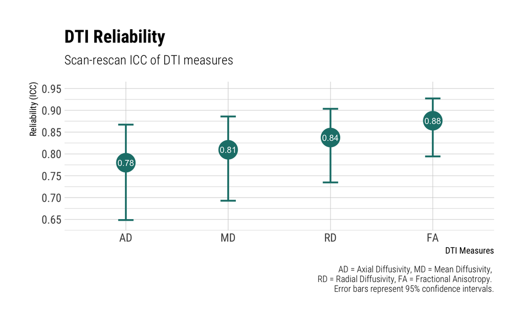

```r
# needs Roboto Condensed font
# https://fonts.google.com/specimen/Roboto+Condensed
# extrafont::font_import()
# extrafont::loadfonts(device="win")

# wrangle data for plot
omni_dat %>%
  group_by(dat) %>%
  summarise(ICC = mean(ICC),
            lower = mean(`2.5% CI`),
            upper = mean(`97.5% CI`)
            ) %>%
  # re-order by ICC value
  mutate(dat = fct_reorder(dat, ICC)) %>%
  ggplot(aes(x = dat, y = ICC, label = signif(ICC, 2))) +
  geom_errorbar(aes(ymin = lower, ymax = upper),
                width = 0.15, size = 0.85, color = "#1D7F79") +
  # modern theme w/ roboto font
  hrbrthemes::theme_ipsum_rc() +
  geom_point(size = 8.5, color = "#1D7F79") +
  geom_text(color = "white", size = 3) +
  scale_y_continuous(limits = c(0.64, 0.95),
                     breaks = seq(0.65, 1, 0.05)) +
  labs(title = "DTI Reliability",
       subtitle = "Scan-rescan ICC of DTI measures",
       x = "DTI Measures",
       y = "Reliability (ICC)",
       caption = "AD = Axial Diffusivity, MD = Mean Diffusivity,
       RD = Radial Diffusivity, FA = Fractional Anisotropy.
       Error bars represent 95% confidence intervals.")

# save plot
ggsave("figs/DTI_ICC_Plot.png", dpi = 300, # change for pub
       width = 7.25, height = 5)
```